# **Big Data Analytics [CN7031] CRWK 2021-22**

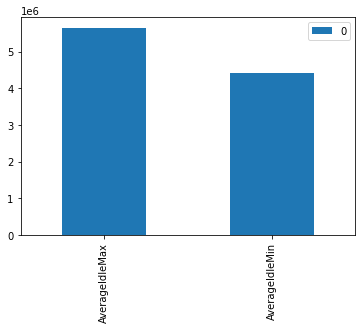

```python
# Create bar graoh

pandas_ave_21 = sqlDf_list_dist_std22.toPandas()
df_tr = pandas_ave_21.transpose()
df_tr.plot(kind = 'bar')
```

*Student 3 : Yasin Shaik and u2166171*

```
+--------------------+----------+------------+
|               Label|GroupLabel|TotalDstPort|
+--------------------+----------+------------+
|              Benign|         0|     5329908|
|      FTP-BruteForce|         0|      193360|
|      SSH-Bruteforce|         0|      187589|
|DoS attacks-Golde...|         0|       41508|
|DoS attacks-Slowl...|         0|       10990|
|    DoS attacks-Hulk|         0|      461912|
|DoS attacks-SlowH...|         0|      139890|
|    DDOS attack-HOIC|         0|      686012|
|DDOS attack-LOIC-UDP|         0|        1730|
|    Brute Force -XSS|         0|         230|
|       SQL Injection|         0|          87|
|    Brute Force -Web|         0|         611|
|                 Bot|         0|      286191|
|                null|         1|     7340018|
+--------------------+----------+------------+
```

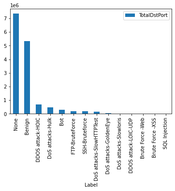

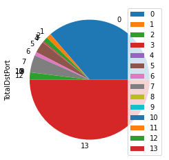

```python
# Student 3 : Yasin Shaik and u2166171
# Query 1 [Briefly explain]: Total destinaton port of Label. I am using grouping() pre define function accomplished this task.

sqlDf_list_grouping_label_31 = spark.sql("SELECT Label, grouping(Label) AS GroupLabel, count(`Dst Port`) AS TotalDstPort FROM IDS2018 GROUP BY cube(Label)")
sqlDf_list_grouping_label_31.show()

pandas_list_grouping_label_31 = sqlDf_list_grouping_label_31.toPandas()
pandas_list_grouping_label_31.sort_values(by='TotalDstPort',ascending=False).plot(x ='Label', y='TotalDstPort', kind = 'bar')
pandas_list_grouping_label_31.plot(x ='Label', y='TotalDstPort', kind = 'pie')
```

```
+--------------------------------+--------------------------------------+
|corr(Tot Bwd Pkts, Tot Fwd Pkts)|corr(TotLen Fwd Pkts, TotLen Bwd Pkts)|
+--------------------------------+--------------------------------------+
|             0.02771364973463959|                  0.002063909240911181|
+--------------------------------+--------------------------------------+
```

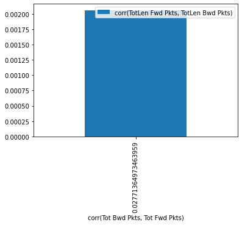

```python
# Student 3 : Yasin Shaik and u2166171
# Query 2 [Briefly explain]: Returns the  corelation of a Tot Bwd Pkts and Tot Bwd Pkts

# sqlDf_list_corr_321 = spark.sql("SELECT  corr(`Tot Bwd Pkts`, `Tot Fwd Pkts`)  ,  corr(`TotLen Fwd Pkts`, `TotLen Bwd Pkts`),  corr(`Fwd Pkt Len Max`, `Fwd Pkt Len Min`)  FROM IDS2018")
sqlDf_list_corr_321 = spark.sql("SELECT  corr(`Tot Bwd Pkts`, `Tot Fwd Pkts`)  ,  corr(`TotLen Fwd Pkts`, `TotLen Bwd Pkts`)  FROM IDS2018")
sqlDf_list_corr_321.show()



pandas_list_corr_32 = sqlDf_list_corr_321.toPandas()
pandas_list_corr_32.plot(x ='corr(Tot Bwd Pkts, Tot Fwd Pkts)', y='corr(TotLen Fwd Pkts, TotLen Bwd Pkts)', kind = 'bar')
# pandas_list_corr_32.plot(x ='corr(Tot Bwd Pkts, Tot Fwd Pkts)', y='corr(TotLen Fwd Pkts, TotLen Bwd Pkts)', kind = 'pie')
```

*Student 4 : Asif Kamal Ansari and u2175442*

Analysis average duration of data flow for distinct label values

1. Call the average (*AVG*) spark SQL method to get average duration.
2. The *BROUND* method will take two decimal average data 3.The output should be display in Duration asscending order

```python
# Student 4 : Asif Kamal Ansari and u2175442
# Query 1 [Briefly explain]:  Get Total average Flow duration for Lable.
#                             Here I am trying to found out average duration flow of packets against every Lable values

sqlDf_approx_average = spark.sql("SELECT Label,  BROUND( AVG(`Flow Duration`), 2) AvgFlowDuration  FROM IDS2018   GROUP BY  Label ORDER BY AvgFlowDuration")
sqlDf_approx_average.show()
```

```
+--------------------+---------------+
|               Label|AvgFlowDuration|
+--------------------+---------------+
|      FTP-BruteForce|            3.8|
|DoS attacks-SlowH...|            4.9|
|    DDOS attack-HOIC|        9720.32|
|                 Bot|       75298.91|
|      SSH-Bruteforce|      183349.68|
|    DoS attacks-Hulk|      301755.61|
|       SQL Injection|     3315726.93|
|DoS attacks-Golde...|  1.123344051E7|
|              Benign|   1.31734914E7|
|    Brute Force -XSS|  2.866269783E7|
|    Brute Force -Web|  3.544130447E7|
|DoS attacks-Slowl...|  7.198033627E7|
|DDOS attack-LOIC-UDP|  1.160181693E8|
+--------------------+---------------+
```

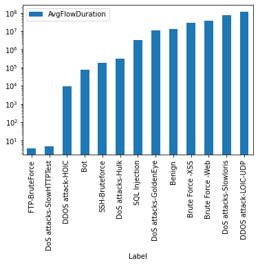

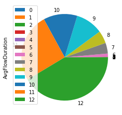

```python
# Generate visual description
pdDf_approx_average = sqlDf_approx_average.toPandas()
pdDf_approx_average.plot(x ='Label', y='AvgFlowDuration', kind = 'bar', logy = True)
pdDf_approx_average.plot(x ='Label', y='AvgFlowDuration', kind = 'pie')
```

```python
# Student 4 : Asif Kamal Ansari and u2175442
# Query 2 [Briefly explain]: Compare the packet size in bakd an fourth against the PHS flag and find out which option is best.
#                            The TCP protocal has Push and Urgent atribure to make package. The PHS(Push) flag is one data
#                            shoud be push everytime while generating sopacket size shoudl be more.

sqlDf_PHS_PacketSize = spark.sql("SELECT `Fwd PSH Flags` ,BROUND( SUM(`Fwd Pkts/s`),2) AS FwdPacketSize FROM IDS2018 GROUP BY `Fwd PSH Flags`")
sqlDf_BHS_PacketSize = spark.sql("SELECT `Bwd PSH Flags` , BROUND(SUM(`Bwd Pkts/s`),2) AS BwdPacketSize FROM IDS2018 GROUP BY `Bwd PSH Flags`")

sqlDf_PHS_PacketSize.show()
sqlDf_BHS_PacketSize.show()
```

```
+-------------+------------------+
|Fwd PSH Flags|     FwdPacketSize|
+-------------+------------------+
|            1| 3.133869209181E10|
|            0|2.7727788520181E11|
+-------------+------------------+

+-------------+------------------+
|Bwd PSH Flags|     BwdPacketSize|
+-------------+------------------+
|            0|1.9656549226036E11|
+-------------+------------------+
```

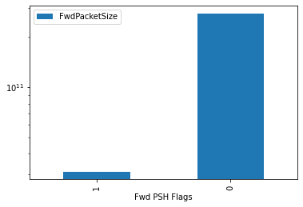

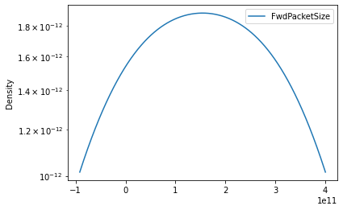

```python
# Create visual representation in par and density graph
pdDf_PHS_PacketSize = sqlDf_PHS_PacketSize.toPandas()
pdlDf_BHS_PacketSize= sqlDf_BHS_PacketSize.toPandas()
pdDf_PHS_PacketSize.plot(x ='Fwd PSH Flags', y='FwdPacketSize', kind = 'bar', logy = True)
pdDf_PHS_PacketSize.plot(x ='Fwd PSH Flags', y='FwdPacketSize', kind = 'density', logy = True)
```

# **Task 2 - Part1: PySpark [45 marks]**

```python
# Student 1 : Vinay kumar Yadav and u2091585
# Analytical method 1: Descriptive Statistics -
```

Descriptive Statistics

1. Find out column and extract and create summarise dataframe
2. Clean data - removed null vlaue and empty records
3. Filter and show the records
4. Calculate Descriptive Statistics like Average , Minimum and Maximum

```python
### Create new datafrom for feature 'Down/Up Ratio'
DES_IDS_df = IDS_df.select('Down/Up Ratio')

### Describe the values
print("\n Describe column summary")
DES_IDS_df.select(['Down/Up Ratio']).describe().show()
print("\n")
DES_IDS_df.select([mean('Down/Up Ratio'), min('Down/Up Ratio'), max('Down/Up Ratio')]).show()
```

```
 Describe column summary
+-------+------------------+
|summary|     Down/Up Ratio|
+-------+------------------+
|  count|           1048575|
|   mean|0.6634537348306034|
| stddev|0.5652833371543783|
|    min|                 0|
|    max|                80|
+-------+------------------+

+------------------+------------------+------------------+
|avg(Down/Up Ratio)|min(Down/Up Ratio)|max(Down/Up Ratio)|
+------------------+------------------+------------------+
|0.6634537348306034|                 0|                80|
+------------------+------------------+------------------+
```

```python
# Student 1 : Vinay kumar Yadav and u2091585
# Analytical method 2: Descriptive Statistics
```

1. Find out column and extract and create summarise dataframe
2. Clean data - removed null vlaue and empty records
3. Filter and show the records
4. Calculate Descriptive Statistics like Counr , average , Minimum and Maximum

```python
### Create new datafrom for feature 'Fwd PSH Flags'
DES_IDS_df_s1a2 = IDS_df.select('Fwd PSH Flags')
DES_IDS_df_s1a2.groupBy('Fwd PSH Flags').count().show()
DES_IDS_df_s1a2.groupBy('Fwd PSH Flags').mean().show()
DES_IDS_df_s1a2.groupBy('Fwd PSH Flags').min().show()
DES_IDS_df_s1a2.groupBy('Fwd PSH Flags').max().show()
```

```
+-------------+-------+
|Fwd PSH Flags|  count|
+-------------+-------+
|            1|  27886|
|            0|1020689|
+-------------+-------+

+-------------+------------------+
|Fwd PSH Flags|avg(Fwd PSH Flags)|
+-------------+------------------+
|            1|               1.0|
|            0|               0.0|
+-------------+------------------+

+-------------+------------------+
|Fwd PSH Flags|min(Fwd PSH Flags)|
+-------------+------------------+
|            1|                 1|
|            0|                 0|
+-------------+------------------+

+-------------+------------------+
|Fwd PSH Flags|max(Fwd PSH Flags)|
+-------------+------------------+
|            1|                 1|
|            0|                 0|
+-------------+------------------+
```

```python
# Student 1 : Vinay kumar Yadav and u2091585
# Analytical method 3: Correlation
```

Correlation

1. Find out column and extract and create dataframe
2. Create Vector series and assembled using Vector Assembler
3. Filter and show the records
4. Calclation the correlation between two series of 'Tot Fwd Pkts', 'Tot Bwd Pkts'

```python
assembler = VectorAssembler(
  inputCols = ['Tot Fwd Pkts', 'Tot Bwd Pkts']
  , outputCol = "features"
)
vector_df = IDS_df.select(['Tot Fwd Pkts', 'Tot Bwd Pkts'])
#vector_df.take(20)
assembled_vector_df = assembler.transform(vector_df)

r1 = Correlation.corr(assembled_vector_df, "features").head()
print("Pearson correlation matrix:\n" + str(r1[0]))

r2 = Correlation.corr(assembled_vector_df, "features", "spearman").head()
print("Spearman correlation matrix:\n" + str(r2[0]))
```

```
Pearson correlation matrix:
DenseMatrix([[1.        , 0.88443472],
             [0.88443472, 1.        ]])
Spearman correlation matrix:
DenseMatrix([[1.        , 0.66143616],
             [0.66143616, 1.        ]])
```

Sort out maximum and most frequently used attack

1. Call the groupby function of aggregate output.
2. Here I am using Over(window)) functions operate on a group of rows and return a single value for every input row
3. I have added Total and Percentage using withColumn

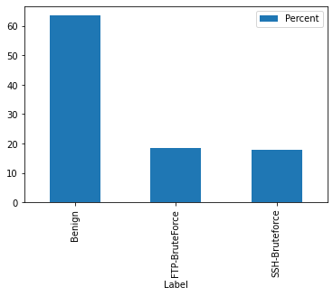

```python
# Student 2 : Siddharth Dholu and u2165171
# Analytical method 1: Sort out maximum and most frequently used attack

colAttack = 'Label'

attackDistribution = IDS_df.select([colAttack]).\
              groupBy(colAttack).\
                agg(
                    func.count(colAttack).alias('Attack_COUNT')).\
                  withColumn('total', sum(col('Attack_COUNT')).over(window)).\
                  withColumn('Percent', col('Attack_COUNT')*100/ col('total')).\
                  drop(col('total')).\
                  sort(desc('Percent'))

dfattackDistribution = attackDistribution.toPandas()
dfattackDistribution

fig = dfattackDistribution.plot.bar(x='Label', y='Percent', rot=90)
```

```python
# Student 2 : Siddharth Dholu and u2165171
# Analytical method 2: Covariance-
```

Covariance-

Check the how the respected variance to each other. Here we check two variable Total Length forward packets and total length of backword length.

I have selected 'TotLen Fwd Pkts', 'TotLen Bwd Pkts'] from DataFrame.

I used COV() method of STAT class to get variance.

```python
IDS_df_cov22 = IDS_df.select(['TotLen Fwd Pkts', 'TotLen Bwd Pkts'])
IDS_df_cov22.stat.cov('TotLen Fwd Pkts', 'TotLen Bwd Pkts')
```

```
29535668.14993694
```

```python
# Student 2 : Siddharth Dholu and u2165171
# Analytical method 3: Find highest Standard deviation length of a flow in packet size.
```

Find out highest hit of packet size.

```python
IDS_df_23 = IDS_df.select(["Pkt Len Std"])
IDS_df_23.groupBy("Pkt Len Std").count().orderBy('count', ascending=False).show(10)
```

```
+--------------+------+
|   Pkt Len Std| count|
+--------------+------+
|           0.0|464232|
|   9.237604307| 43175|
|173.7875858627| 21228|
| 80.0048609634| 20477|
|203.7371995112| 16545|
|203.7409674518| 16522|
|319.3627965705| 13345|
| 21.6852484422| 12817|
| 319.433241591| 12149|
| 18.4752086141| 10380|
+--------------+------+
only showing top 10 rows
```

```python
# Student 3 : Yasin Shaik and u2166171
# Analytical method 1: Frequent Items
```

Return list of recent records from selected column.

Select column "Label", "Init Fwd Win Byts" and "Init Bwd Win Byts"

The .**freqItems**() transformation give the list of frequent item.

In out put show recent frequently selected records.

```python
freqColumn = ["Label", "Init Fwd Win Byts", "Init Bwd Win Byts" ]
IDS_df_freq31 = IDS_df.select(freqColumn)
IDS_df_freq31_res =  IDS_df_freq31.stat.freqItems(freqColumn, 0.4)
IDS_df_freq31_res.show(20)
```

```
+--------------------+---------------------------+---------------------------+
|     Label_freqItems|Init Fwd Win Byts_freqItems|Init Bwd Win Byts_freqItems|
+--------------------+---------------------------+---------------------------+
|[FTP-BruteForce, ...|              [8192, 26883]|                    [-1, 0]|
+--------------------+---------------------------+---------------------------+
```

```python
# Student 3 : Yasin Shaik and u2166171
# Analytical method 2:  Call Sample Method
```

Select random records from DataFrame.

I have sort out 'Bwd IAT Min' to check sample data.

Here I use **Sample** method to get random records.

In output show the random selected records

```python
IDS_df_sample32 = IDS_df.select('Bwd IAT Min')
IDS_df_sample32_res =  IDS_df_sample32.sample(withReplacement=False, fraction=0.5, seed=32)
IDS_df_sample32_res.show(30)
```

```
+-----------+
|Bwd IAT Min|
+-----------+
|        554|
|          0|
|        310|
|        328|
|        341|
|        217|
|        345|
|        186|
|        192|
|        180|
|        173|
|        187|
|        238|
|        195|
|        205|
|        185|
|        184|
|        183|
|          0|
|          0|
|          0|
|          0|
|          0|
|          0|
|          0|
|          0|
|          0|
|          0|
|          0|
|      28398|
+-----------+
only showing top 30 rows
```

```python
# Student 3 : Yasin Shaik and u2166171
# Analytical method 3: Cross Tabulation (Contingency Table)
```

Compute a simple cross tabulation of two ('Dst Port','Label') columns.

Create DataFrame for selected column.

Use **Crosstab** function form Stat library.

The output display in cross format.

```python
IDS_df_crosstab33 = IDS_df.select(['Dst Port','Label' ])
IDS_df_crosstab33.stat.crosstab(  "Dst Port" ,"Label").show(20)
```

```
+--------------+------+--------------+--------------+
|Dst Port_Label|Benign|FTP-BruteForce|SSH-Bruteforce|
+--------------+------+--------------+--------------+
|         53767|     1|             0|             0|
|          8607|     1|             0|             0|
|         60426|     1|             0|             0|
|         64790|     2|             0|             0|
|         55558|     4|             0|             0|
|         53060|     3|             0|             0|
|         49828|    34|             0|             0|
|         50400|    37|             0|             0|
|         54355|     3|             0|             0|
|         50665|    24|             0|             0|
|         51261|    20|             0|             0|
|         16216|     2|             0|             0|
|         64943|     2|             0|             0|
|         54422|     1|             0|             0|
|         49767|    31|             0|             0|
|          7375|     1|             0|             0|
|         41894|     1|             0|             0|
|         62382|     1|             0|             0|
|         61456|     2|             0|             0|
|         59593|     3|             0|             0|
+--------------+------+--------------+--------------+
only showing top 20 rows
```

```python
# Student 4 : Asif Kamal Ansari and u2175442
# Analytical method 1: Hypothesis testing
```

**Hypothesis** normally use the unit testing. Here we write test to find that something should be true for every case. It basically checks the that happen by chance or not. The method *Test* of *ChiSquareTest* class that is *available in pyspark.ml.stat* .

1. Sort out input colmn from given data set
2. Create one vector dense schema with sort out column
3. Create DataFrame of sort out column
4. Assembled the DataFrame with Vector dense schema
5. Use test method of ChisuareTest
6. Show the output

```python
inputCols42 = ['Fwd Header Len','Bwd Header Len' ]
assembler42 = VectorAssembler(
      inputCols = inputCols42
      , outputCol = "features"
)
vector_IDS_df42 = IDS_df.select(inputCols42)
# IDS_df21.take(20)

assembled_vector_df42 = assembler42.transform(vector_IDS_df42)
chi = ChiSquareTest.test(assembled_vector_df42, "features", "Fwd Header Len")
chi.show(truncate=False)
```

```
+---------+------------------+----------------------------------------+
|pValues  |degreesOfFreedom  |statistics                              |
+---------+------------------+----------------------------------------+
|[0.0,0.0]|[1527696, 2276712]|[1.296038699999464E9,7.17894186485613E8]|
+---------+------------------+----------------------------------------+
```

```python
# Student 4 : Asif Kamal Ansari and u2175442
# Analytical method 2: Skewness
```

**Skewness** is the measure of an asymmetric distribution and value will be positive or newgative. Here calculate the Skewness of distribution of **IAT** (Inter Arrival Time) records We are using *skewness()* that available in *pyspark.sql.functions*.

1. Select feature columns.
2. Filter DataFrame of selected feature column.
3. Call method skewness and pass selected column.
4. Returns the skewness of the values in a group.

```python
feature_col = ['Flow IAT Min', 'Fwd IAT Tot','Fwd IAT Mean','Fwd IAT Std']
skewness_df = IDS_df.select(feature_col)
skewness_df = skewness_df.select(func.skewness(skewness_df['Flow IAT Min']), func.skewness(skewness_df[ 'Fwd IAT Tot']) , func.skewness(skewness_df['Fwd IAT Mean']), func.skewness(skewness_df['Fwd IAT Std']))
skewness_df.show(20)
```

```
+----------------------+---------------------+----------------------+---------------------+
|skewness(Flow IAT Min)|skewness(Fwd IAT Tot)|skewness(Fwd IAT Mean)|skewness(Fwd IAT Std)|
+----------------------+---------------------+----------------------+---------------------+
|    -539.1018634277009|   -601.1688088749935|   -1019.1794068473234|    532.9826675365141|
+----------------------+---------------------+----------------------+---------------------+
```

**Skewness Output**: we can see hare the value in group is positive and negative for different column

Find out highest attacked day.

```python
# Student 4 : Asif Kamal Ansari and u2175442
# Analytical method 3: Compare Label that have higest attacked day.
#                      The output showed that 14-Feb-208 was heights attacked
```

```python
IDS_df_43 = IDS_df.select(["Timestamp", "Label"])
NoOfLabel = IDS_df_43.select(["Label"]).distinct().count()
IDS_df_Date43 = IDS_df_43.withColumn('Timestamp', func.substring('Timestamp', 1,10))
IDS_df_Date43.groupBy(["Timestamp", "Label"]).count().orderBy('count', ascending=False).show(NoOfLabel)
```

```
+----------+--------------+------+
| Timestamp|         Label| count|
+----------+--------------+------+
|14/02/2018|        Benign|667621|
|14/02/2018|FTP-BruteForce|193360|
|14/02/2018|SSH-Bruteforce|187589|
+----------+--------------+------+
only showing top 3 rows
```

# **Task 2 - Part2: PySpark [15 marks]**

```python
# Student : Vinay kumar Yadav and u2091585
# Machine Learning Technique:  Logistic Regression
# What to achieve:

selected_columns =  ['Dst Port',
 'Protocol',
 'Tot Fwd Pkts',
 'Tot Bwd Pkts',
 'FIN Flag Cnt',
 'SYN Flag Cnt',
 'RST Flag Cnt',
 'PSH Flag Cnt',
 'ACK Flag Cnt',
 'URG Flag Cnt',
 'CWE Flag Count',
 'ECE Flag Cnt',
 'Label']
data = IDS_df[selected_columns]
data.printSchema()

convertedData = data.withColumn("Label_Numeric", func.dense_rank().over(Window.orderBy("Label")))
convertedData = convertedData.drop(col("Label"))
convertedData.show(5)
```

```
root
 |-- Dst Port: integer (nullable = true)
 |-- Protocol: integer (nullable = true)
 |-- Tot Fwd Pkts: integer (nullable = true)
 |-- Tot Bwd Pkts: integer (nullable = true)
 |-- FIN Flag Cnt: integer (nullable = true)
 |-- SYN Flag Cnt: integer (nullable = true)
 |-- RST Flag Cnt: integer (nullable = true)
 |-- PSH Flag Cnt: integer (nullable = true)
 |-- ACK Flag Cnt: integer (nullable = true)
 |-- URG Flag Cnt: integer (nullable = true)
 |-- CWE Flag Count: integer (nullable = true)
 |-- ECE Flag Cnt: integer (nullable = true)
 |-- Label: string (nullable = true)

+--------+--------+------------+------------+------------+------------+------------+------------+------------+------------+--------------+------------+-------------+
|Dst Port|Protocol|Tot Fwd Pkts|Tot Bwd Pkts|FIN Flag Cnt|SYN Flag Cnt|RST Flag Cnt|PSH Flag Cnt|ACK Flag Cnt|URG Flag Cnt|CWE Flag Count|ECE Flag Cnt|Label_Numeric|
+--------+--------+------------+------------+------------+------------+------------+------------+------------+------------+--------------+------------+-------------+
|       0|       0|           3|           0|           0|           0|           0|           0|           0|           0|             0|           0|            1|
|       0|       0|           3|           0|           0|           0|           0|           0|           0|           0|             0|           0|            1|
|       0|       0|           3|           0|           0|           0|           0|           0|           0|           0|             0|           0|            1|
|      22|       6|          15|          10|           0|           0|           0|           1|           0|           0|             0|           0|            1|
|      22|       6|          14|          11|           0|           0|           0|           1|           0|           0|             0|           0|            1|
+--------+--------+------------+------------+------------+------------+------------+------------+------------+------------+--------------+------------+-------------+
only showing top 5 rows
```

```python
convertedData.select("Label_Numeric").distinct().show()

assembler_inputs = [x for x in list(convertedData.columns)]
assembler_inputs

vector_assembler = VectorAssembler(inputCols=assembler_inputs, outputCol="VectorAssemblerFeatures")

stages = []
stages += [vector_assembler]
stages

pipeline = Pipeline().setStages(stages)
model = pipeline.fit(convertedData)
pp_df = model.transform(convertedData)
pp_df.show(5, truncate=False)
```

```
+-------------+
|Label_Numeric|
+-------------+
|            1|
|            2|
|            3|
|            4|
|            5|
|            6|
|            7|
|            8|
|            9|
|           10|
|           11|
|           12|
|           13|
+-------------+

+--------+--------+------------+------------+------------+------------+------------+------------+------------+------------+--------------+------------+-------------+-------------------------------------------+
|Dst Port|Protocol|Tot Fwd Pkts|Tot Bwd Pkts|FIN Flag Cnt|SYN Flag Cnt|RST Flag Cnt|PSH Flag Cnt|ACK Flag Cnt|URG Flag Cnt|CWE Flag Count|ECE Flag Cnt|Label_Numeric|VectorAssemblerFeatures                    |
+--------+--------+------------+------------+------------+------------+------------+------------+------------+------------+--------------+------------+-------------+-------------------------------------------+
|0       |0       |3           |0           |0           |0           |0           |0           |0           |0           |0             |0           |1            |(13,[2,12],[3.0,1.0])                      |
|51401   |6       |2           |0           |0           |0           |0           |0           |1           |0           |0             |0           |1            |(13,[0,1,2,8,12],[51401.0,6.0,2.0,1.0,1.0])|
|0       |0       |3           |0           |0           |0           |0           |0           |0           |0           |0             |0           |1            |(13,[2,12],[3.0,1.0])                      |
|53      |17      |1           |1           |0           |0           |0           |0           |0           |0           |0             |0           |1            |(13,[0,1,2,3,12],[53.0,17.0,1.0,1.0,1.0])  |
|0       |0       |3           |0           |0           |0           |0           |0           |0           |0           |0             |0           |1            |(13,[2,12],[3.0,1.0])                      |
+--------+--------+------------+------------+------------+------------+------------+------------+------------+------------+--------------+------------+-------------+-------------------------------------------+
only showing top 5 rows
```

```python
lr_df = pp_df.select(
    func.col("VectorAssemblerFeatures").alias("features"),
    func.col("Label_Numeric").alias("label"),
)
lr_df.show(5, truncate=False)
```

```
+-------------------------------------------+-----+
|features                                   |label|
+-------------------------------------------+-----+
|(13,[2,12],[3.0,1.0])                      |1    |
|(13,[0,1,2,8,12],[51401.0,6.0,2.0,1.0,1.0])|1    |
|(13,[2,12],[3.0,1.0])                      |1    |
|(13,[0,1,2,3,12],[53.0,17.0,1.0,1.0,1.0])  |1    |
|(13,[2,12],[3.0,1.0])                      |1    |
+-------------------------------------------+-----+
only showing top 5 rows
```

```python
# Spliting the data for training and testing where 70 percent is for training data and 30 percent for testing data.
train, test = lr_df.randomSplit([0.7,0.3], seed=7)

lr = LogisticRegression(featuresCol="features", labelCol="label", maxIter=5)
lr_model = lr.fit(train)
prediction = lr_model.transform(test)


from pyspark.ml.evaluation import MulticlassClassificationEvaluator
eval = MulticlassClassificationEvaluator()
accuracy_res = eval.evaluate(prediction)
print(accuracy_res)
```

```
0.8924108806532258
```

.

.

```python
# Student 2 : Siddharth Dholu and u2165171
# Machine Learning Technique: Decision Tree Classifier
# What to achieve:

from pyspark.ml.feature import StringIndexer
from pyspark.ml.feature import VectorAssembler
from pyspark.ml.classification import DecisionTreeClassifier
from pyspark.ml.evaluation import MulticlassClassificationEvaluator
```

**Decision Tree Classifier**

Decision tree classifier algorithm is for making the classification. And It supports binary classification where there are only two classes for prediction and as well as it supports multiclass classification where there are more than two classes to predict. It also supports continuous (Number Prediction) and categorical (Label Prediction) features.

Imported Required Libraries for Decision Tree Classification:

1. **StringIndexer**: It converts catogorical column values into numeric value.
2. **VectorAssembler**: It merges feature columns (except label column) values into one single column (array format).
3. **DecisionTreeClassifier**: It is a algorithm that helps us to predict the problems which includes both catogorical and as well as continuous. It has many parameters to config the model for better accuracy and prediction.
4. **MulticlassClassificationEvaluator**: With the help of MulticlassClassificationEvaluator we can calculate accuracy where it expects predictions from algorithm.

```python
filteredData = IDS_df.select(['Dst Port',
 'Protocol',
 'Flow Duration',
 'Tot Fwd Pkts',
 'Tot Bwd Pkts',
 'Flow IAT Mean',
 'Fwd IAT Mean',
 'Bwd IAT Mean',
 'Pkt Len Mean',
 'FIN Flag Cnt',
 'SYN Flag Cnt',
 'RST Flag Cnt',
 'PSH Flag Cnt',
 'ACK Flag Cnt',
 'URG Flag Cnt',
 'CWE Flag Count',
 'ECE Flag Cnt',
 'Pkt Size Avg',
 'Active Mean',
 'Idle Mean',
 'Label'])
filteredData.printSchema()
```

```
root
 |-- Dst Port: integer (nullable = true)
 |-- Protocol: integer (nullable = true)
 |-- Flow Duration: long (nullable = true)
 |-- Tot Fwd Pkts: integer (nullable = true)
 |-- Tot Bwd Pkts: integer (nullable = true)
 |-- Flow IAT Mean: double (nullable = true)
 |-- Fwd IAT Mean: double (nullable = true)
 |-- Bwd IAT Mean: double (nullable = true)
 |-- Pkt Len Mean: double (nullable = true)
 |-- FIN Flag Cnt: integer (nullable = true)
 |-- SYN Flag Cnt: integer (nullable = true)
 |-- RST Flag Cnt: integer (nullable = true)
 |-- PSH Flag Cnt: integer (nullable = true)
 |-- ACK Flag Cnt: integer (nullable = true)
 |-- URG Flag Cnt: integer (nullable = true)
 |-- CWE Flag Count: integer (nullable = true)
 |-- ECE Flag Cnt: integer (nullable = true)
 |-- Pkt Size Avg: double (nullable = true)
 |-- Active Mean: double (nullable = true)
 |-- Idle Mean: double (nullable = true)
 |-- Label: string (nullable = true)
```

**filteredData** is a variable of PySpark Dataframe where it containts some specific column names (features) which will help model to perform best prediction and accuracy result.

*Column (Feature) Description as below why we selected these:*

**Dst Port:** Destination Port of victim is most important because various port has different access to the system.

**Protocol:** It has huge role in attack technichs.

**Flow Duration:** What was the duration of attack, long flow duration is more impactful.

**Tot Fwd Pkts:** Total Forward Packets has amount of total travelled request packets.

**Tot Bwd Pkts:** Total Backword Packets has amount of total travelled reponse packet.

**Flow IAT Mean:** Average time between two flows.

**Fwd IAT Mean:** Average time between two packets that requested to victim machine.

**Bwd IAT Mean:** Average time between two packets that sent by server as response.

**Pkt Len Mean:** Average lengh of flow from total flow.

**FIN Flag Cnt:** Number of FIN packets and it is used for close the connection.

**SYN Flag Cnt:** Number of SYN packet and it is used for create a connection.

**RST Flag Cnt:** Number of RST packet and it is used for reset the connection.

**PSH Flag Cnt:** Number of PSH packet and it is used for pushing the packet force-fully.

**ACK Flag Cnt:** Number of ACK packet and it is used for recieving the feedback from packet that recieved.

**URG Flag Cnt:** Number of URG packet and it is used for set the priority to sent packet.

**CWE Flag Count:** Number of CWE packet and it is used for disclosing the information.

**ECE Flag Cnt:** Number of ECE packet and it is used for reduce the tranmission rate.

**Pkt Size Avg:** Average size of each packet.

**Active Mean:** Average time of flow which was active before becoming idle.

**Idle Mean:** Average time where flow was idle before becoming active.

**Label:** It contains different types of attacks and it is main targeted column which we have to predict by appying the Decision Tree Classifer algorythm.

*Attack Types in Label Column:* SSH-Bruteforce, Benign, FTP-BruteForce, DoS attacks-Slowloris, DoS attacks-GoldenEye, DoS attacks-SlowHTTPTest, DoS attacks-Hulk, DDOS attack-LOIC-UDP, DDOS attack-HOIC, SQL Injection, Brute Force -XSS, Brute Force -Web, and Bot

**filteredData.printSchema():** It provides database columns' data type in which column which kind of values are stored, we can decide by seeing the datatype of column that which column(s) needs to convert into required datatype.

```python
columnNames = ['Dst Port',
 'Protocol',
 'Flow Duration',
 'Tot Fwd Pkts',
 'Tot Bwd Pkts',
 'Flow IAT Mean',
 'Fwd IAT Mean',
 'Bwd IAT Mean',
 'Pkt Len Mean',
 'FIN Flag Cnt',
 'SYN Flag Cnt',
 'RST Flag Cnt',
 'PSH Flag Cnt',
 'ACK Flag Cnt',
 'URG Flag Cnt',
 'CWE Flag Count',
 'ECE Flag Cnt',
 'Pkt Size Avg',
 'Active Mean',
 'Idle Mean']

assembler = VectorAssembler(inputCols=columnNames, outputCol='features')
```

**columnNames** is a list of column that contains names as list eliment.

**assembler** is a VectorAssembler variable that has assembler converted data into it.

**VectorAssembler():** It converts the passed columns' values into one column as a array. inputCols param which expects columnNames and outputCol param requires name of produced column after converted into single array. In our case we gave "features" as output column.

```python
assemblerTransform = assembler.transform(filteredData)
```

We are updating pyspark dataframe with newly produced assembler data by using method transform and assigning it into "assemblerTransform" variable.

```python
stringIndexer = StringIndexer(inputCol='Label', outputCol='LabelInt')
stringIndexerTransform = stringIndexer.fit(assemblerTransform).transform(assemblerTransform)
```

We are having our target column or label column with catogorical data, for that we must convert those catogorical data into numerical data with the help of "StringIndexer".

**StringIndexer():** It expects basically two param, inputCol where we have to pass our label column and outputCol where it will create another label column with appropriate format (numeric format) with name of "LabelInt".

Using fit() and transfor() methods, we are adding assembler data to newly genrated string indexer data and updating it by creating another dataframe and assiging entire data into "stringIndexerTransform" variable which is a PySpark dataframe variable.

```python
convertedFilteredData = stringIndexerTransform.select('features','LabelInt')
convertedFilteredData.show()
```

```
+--------------------+--------+
|            features|LabelInt|
+--------------------+--------+
|(20,[2,3,5,6,19],...|     0.0|
|(20,[2,3,5,6,19],...|     0.0|
|(20,[2,3,5,6,19],...|     0.0|
|(20,[0,1,2,3,4,5,...|     0.0|
|(20,[0,1,2,3,4,5,...|     0.0|
|(20,[0,1,2,3,4,5,...|     0.0|
|(20,[2,3,5,6,19],...|     0.0|
|(20,[2,3,5,6,19],...|     0.0|
|(20,[0,1,2,3,4,5,...|     0.0|
|(20,[0,1,2,3,4,5,...|     0.0|
|(20,[0,1,2,3,4,5,...|     0.0|
|(20,[0,1,2,3,4,5,...|     0.0|
|(20,[0,1,2,3,4,5,...|     0.0|
|(20,[0,1,2,3,4,5,...|     0.0|
|(20,[0,1,2,3,4,5,...|     0.0|
|(20,[0,1,2,3,4,5,...|     0.0|
|(20,[0,1,2,3,4,5,...|     0.0|
|(20,[0,1,2,3,4,5,...|     0.0|
|(20,[0,1,2,3,4,5,...|     0.0|
|(20,[0,1,2,3,4,5,...|     0.0|
+--------------------+--------+
only showing top 20 rows
```

We have "stringIndexerTransform" dataframe which contains exist data and new data.

Exist Data: original column and its value.

New Data: converted data and created new columns as features and LabelInt.

Now we only need new data for traing and testing data for model building, so we are just selecting two columns, features and LabelInt and creating new dataframe variable named "convertedFilteredData".

```python
train, test = convertedFilteredData.randomSplit([0.7,0.3], seed=42)
```

We are spliting the data for training and testing using randomSplit() method where we have given 70% train data and 30% test data.

And seed param, we have given 42 which means it will create 42 same instance for random spliting data where we can get same result otherwise if we give seed=None then it will create each and everytime random split data and we get different result each time.

```python
dt = DecisionTreeClassifier(labelCol='LabelInt', featuresCol='features')
dtModel = dt.fit(train)
dtPrediction = dtModel.transform(test)
```

We are creating DecisionTreeClassifier model for the prediction. We have passed labelCol='LabelInt' because in out case we have label column name LabelInt. We must give labelCol name if we don't have labelCol name label. Model has by default labelCol='label' that's why.

```python
dtPrediction.show(5)
```

```
+--------------------+--------+--------------------+--------------------+----------+
|            features|LabelInt|       rawPrediction|         probability|prediction|
+--------------------+--------+--------------------+--------------------+----------+
|(20,[0,1,2,3,4,5,...|     0.0|[2249727.0,0.0,10...|[0.98458305944014...|       0.0|
|(20,[0,1,2,3,4,5,...|     0.0|[2249727.0,0.0,10...|[0.98458305944014...|       0.0|
|(20,[0,1,2,3,4,5,...|     0.0|[2249727.0,0.0,10...|[0.98458305944014...|       0.0|
|(20,[0,1,2,3,4,5,...|     0.0|[2249727.0,0.0,10...|[0.98458305944014...|       0.0|
|(20,[0,1,2,3,4,5,...|     0.0|[2249727.0,0.0,10...|[0.98458305944014...|       0.0|
+--------------------+--------+--------------------+--------------------+----------+
only showing top 5 rows
```

We have shown here dtPrediction where we have tranformed data from DecisionTreeClassifier model. Now we are having features and LabelInt with prediction column.

We can calculate accuracy by going through prediction column values.

```python
evaluator = MulticlassClassificationEvaluator(labelCol='LabelInt', predictionCol='prediction', metricName='accuracy')
accuracy = evaluator.evaluate(dtPrediction)
print(f'Accuracy: {round(accuracy*100, 2)}%')
```

```
Accuracy: 91.01%
```

**MulticlassClassificationEvaluator():** It provides calculation methods for getting accuracy. There are also parameters like labelCol, predictionCol, metricName, and more. In our case, we just need to pass three parameters as per our requirements.